# Home advantage in sport during Covid

Project 3

Football is one of the most popular sports worldwide. Like many other sports, it has been greatly affected by COVID-19. The pandemic has caused big changes in how football matches are played. Many matches have been cancelled or played without fans in the stadiums. Some matches have had limited numbers of spectators allowed. This situation has raised questions about how the absence of fans affects team performance and, in particular, home advantage. Home advantage, which means that teams tend to do better when playing on their own field, has always been considered an important factor in sports. However, during the pandemic the absence of fans has questioned whether the home advantage is actually as beneficial. There has been a growing interest among researchers and fans in studying the impact of COVID-19 on home advantage in football.

For that purpose, we have a complete data set at our disposal, with information on different games. In order to analyze the home effect during covid, we will proceed in six parts. In the first part, we will perform data treatments, including a phase of description and exploration. Then, we will build a model to study the number of goals scored in each game and take time to interpret the results. Furthermore, we will finish by critically examining the created model by studying the diagnostic plots and conducting sensitivity analysis.

# 1 Data Treatments

## 1.1 Description of the Data Set

In order to determine if the home effect has been affected by the COVID, we will construct a model to determine the results of a match. Therefore, we only keep the following variables of the data set: `HomeTeam`, `AwayTeam`, `Referee`, `Goal_Home`, `Goal_away`, and `Covid` (an indicator that we add to determine if we are in the period of Covid, where no spectators are allowed, before or after). An overview of the data set is shown in Figure 1.

Figure 1 : Overview of our Data Set after variables selection.

| HomeTeam | AwayTeam | Home_Goal | Away_Goal | Referee | Covid |
| --- | --- | --- | --- | --- | --- |
| Liverpool | Norwich | 4 | 1 | M Oliver | Before |
| West Ham | Man City | 0 | 5 | M Dean | Before |
| Bournemouth | Sheffield United | 1 | 1 | K Friend | Before |
| … | … | … | … | … | … |

In this data set, we observe that each observation corresponds to a match, where one line groups the information about a match and gives the number of goals scored by a team, and then the opposing team (in two separate columns). However, as mentioned above, our objective is to model the number of goals, so to get around this issue, we can assume that the scores from one team to another in a match are independent and thus duplicate each match. After this modification, we obtain the following data set :

Figure 2 : Overview of our Data Set after duplication of each match.

| Team | Adverse | Goal | Referee | Covid | Home |
| --- | --- | --- | --- | --- | --- |
| Liverpool | Norwich | 4 | M Oliver | Before | TRUE |
| Norwich | Liverpool | 1 | M Oliver | Before | FALSE |
| West Ham | Man City | 0 | M Dean | Before | TRUE |
| … | … | … | … | … | … |

In the end, the data set contains six variables :

- `Team`, the team observed in a particular match
- `Goal`, the variable of interest that determines the number of goals scored during the game by this team
- `Adverse`, the opposing team in the game
- `home`, an indicator that informs if the team plays at home or not
- `Covid`, an indicator indicating if the match took place before, during, or after the covid pandemic
- `Referee`, the referee of the match.

## 1.2 Exploration Part

Now that we have described the data set, we can begin the exploration part, which naturally starts with the variable of interest: `Goal`.

It is a variable that takes values in 0, 1, 2, …., so entire positive values. Therefore it can be characterized as a count variable. This precious information will guide us in the next step through a Poisson regression method, which is very popular and useful in these problems. Moreover the minimum value is 0 and the maximum value is 9.

One good way to confirm the intuition that the poisson model can be good one is to compare our variable `Goal` with a sample from a Poisson distribution with mean 1.39 (the mean of our observations). This is shown in Figure 3, and we notice that both histograms are highly similar, which is quite encouraging.

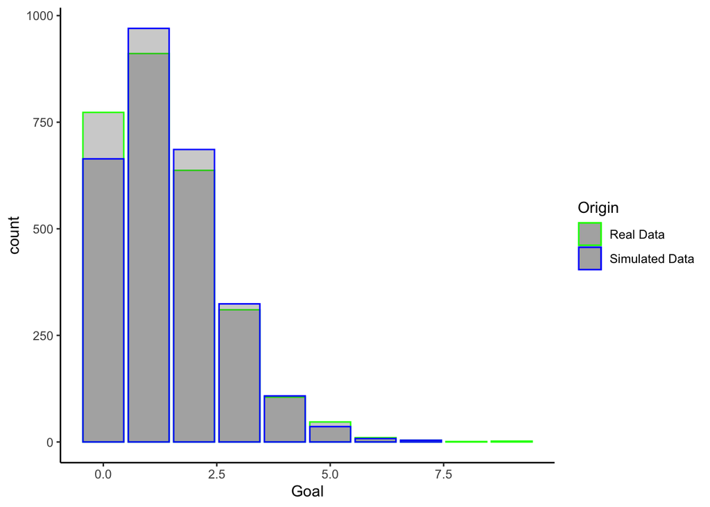

Figure 3: Histogram for the `Goal` variable and a sample from poisson distribution.

Keeping sight of our objectives, we are curious to find out if the data shows any obvious signs of impact during covid. The idea is to represent for each number of goals and each period of the covid, the proportion of goals scored at home (Figure 4). For instance, during the ‘pre-covid’ period, of all the teams that scored 5 goals, 70% were playing at home.

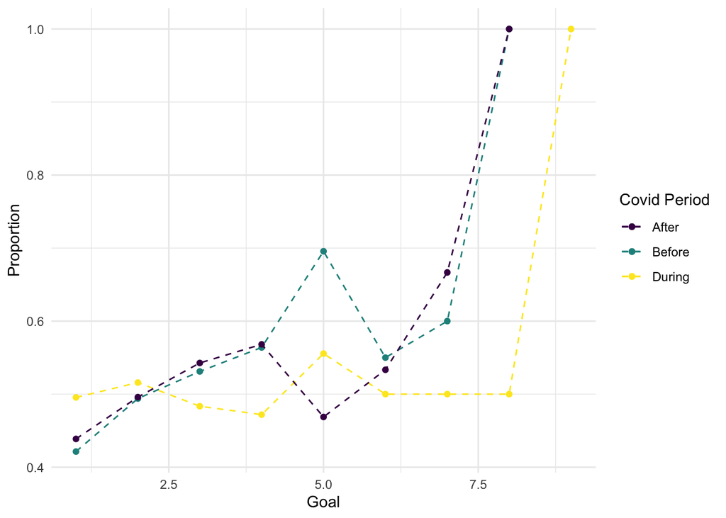

Figure 4: Proportion of goals scored at home for each covid’s periods.

This graph is particularly interesting since it emphasizes several aspects.

Another point to note is that the two curves corresponding to before and after covid, are roughly similar (except for the value 5). Contrary to the curve during covid which is lower than the other two and remains relatively constant (around 0.5). This graph leads us to think that the home effect was diminished during the covid period, whereas without the audience it would have disappeared.

# 2 Regression

## 2.1 Poisson family

As explained in the previous part, the variable of interest (`Goal`) is a ‘count variable’, it counts the number of goals in a match by a certain team. As it takes values in $\mathbb{N}$, the Poisson model seems to be the most suitable for representing it.

Moreover we can note that the poisson distribution is of the exponential type. Indeed, the density can be written :

$$f(x, \lambda) =
\frac{\lambda^x}{x!}\exp(-\lambda)$$
$$f(x, \lambda) = \exp(x \log(\lambda) - \lambda +
\log(\frac{1}{x!}))$$
$$f(x, \theta) =
\exp(x \theta - \exp(\theta) + \log(\frac{1}{x!}))$$
with $\theta = \log(\lambda)$

From here we can see that $\mu = \mathbb{E}[Y] = \lambda = \exp(\theta)$ and we can easily deduce that the canonical link is actually the log-link : $g(\lambda) = \log(\lambda) = \theta = X\beta$.

## 2.2 Application

In statistics, when applying regression analysis, it is necessary to make certain assumptions regarding the regression and the specific type of regression being used.

The first one is that all the observations must be independent. That is why before to duplicate each match we make the hypothesis that the score of a team and the adverse in the same match must not be dependent.

The second one is related to the Poisson regression method, the mean and the variance of the variable of interest are assumed to be equal. This is indeed a characteristic of the Poisson distribution. Nevertheless, this can be a very constraining restriction and can lead to problems such as overdispersion.

That being said, we start by performing a regression analysis on all the variables that we have. This analysis will help us determine which variables serve as significant predictors of the number of goal, and which ones do not. By identifying the non-significant variables, we can potentially simplify our model by removing them.

However, our previous exploration showed that the covid might eventually have an effect. We can therefore put an interaction between the variables `home` and `covid`. And it turns out to be a meaningful interaction. In the same way, adding an interaction between `adverse` and `covid` improves the result.

*Note : We can note that we tested several other interactions that could make sense as between the variables `home` and `Team`. However, none of them seems to be significant and does not lower the AIC.*

In the end, we obtain the following model :

`Goal` ~ `Team` + `Adverse` + (`Adverse` + `home`) * `covid`

And we can print the summary.

```
##
## Call:
## glm(formula = Goal ~ Team + Adverse + (home + Adverse) * covid,
##     family = poisson(link = log), data = Data)
##
## Coefficients: (15 not defined because of singularities)
##                                      Estimate Std. Error z value Pr(>|z|)
## (Intercept)                          0.285141   0.163450   1.745 0.081068 .
## TeamAston Villa                     -0.132346   0.107863  -1.227 0.219831
## TeamBournemouth                     -0.243350   0.130605  -1.863 0.062425 .
## TeamBrentford                       -0.225726   0.161537  -1.397 0.162303
## TeamBrighton                        -0.421996   0.105983  -3.982 6.84e-05 ***
## TeamBurnley                         -0.453179   0.107367  -4.221 2.43e-05 ***
## TeamCardiff                         -0.608777   0.185157  -3.288 0.001009 **
## TeamChelsea                          0.053987   0.092970   0.581 0.561445
## TeamCrystal Palace                  -0.304082   0.102693  -2.961 0.003066 **
## TeamEverton                         -0.229353   0.100462  -2.283 0.022431 *
## TeamFulham                          -0.681262   0.144966  -4.699 2.61e-06 ***
## TeamHuddersfield                    -1.038073   0.224338  -4.627 3.71e-06 ***
## TeamLeeds                           -0.121384   0.119828  -1.013 0.311069
## TeamLeicester                        0.046942   0.093431   0.502 0.615369
## TeamLiverpool                        0.312930   0.087615   3.572 0.000355 ***
## TeamMan City                         0.410275   0.085894   4.777 1.78e-06 ***
## TeamMan United                       0.040111   0.093669   0.428 0.668492
## TeamNewcastle                       -0.356171   0.104382  -3.412 0.000644 ***
## TeamNorwich                         -0.746547   0.161212  -4.631 3.64e-06 ***
## TeamSheffield United                -0.730520   0.159809  -4.571 4.85e-06 ***
## TeamSouthampton                     -0.273785   0.102302  -2.676 0.007445 **
## TeamTottenham                        0.087284   0.092333   0.945 0.344493
## TeamWatford                         -0.396156   0.116957  -3.387 0.000706 ***
## TeamWest Brom                       -0.494555   0.184097  -2.686 0.007223 **
## TeamWest Ham                        -0.087126   0.096830  -0.900 0.368236
## TeamWolves                          -0.362130   0.104323  -3.471 0.000518 ***
## AdverseAston Villa                   0.110394   0.198462   0.556 0.578042
## AdverseBournemouth                   0.253041   0.144699   1.749 0.080336 .
## AdverseBrentford                     0.142134   0.196864   0.722 0.470299
## AdverseBrighton                     -0.107399   0.208774  -0.514 0.606954
## AdverseBurnley                       0.077524   0.199316   0.389 0.697312
## AdverseCardiff                       0.284170   0.162199   1.752 0.079776 .
## AdverseChelsea                      -0.371369   0.226204  -1.642 0.100643
```

[output cut: 68 more lines]

```
## AdverseTottenham:covidDuring         0.325539   0.306098   1.064 0.287550
## AdverseWatford:covidDuring                 NA         NA      NA       NA
## AdverseWest Brom:covidDuring               NA         NA      NA       NA
## AdverseWest Ham:covidDuring          0.125856   0.295565   0.426 0.670243
## AdverseWolves:covidDuring            0.397304   0.298263   1.332 0.182840
## ---
## Signif. codes:  0 '***' 0.001 '**' 0.01 '*' 0.05 '.' 0.1 ' ' 1
##
## (Dispersion parameter for poisson family taken to be 1)
##
##     Null deviance: 3624.8  on 2799  degrees of freedom
## Residual deviance: 2988.9  on 2709  degrees of freedom
## AIC: 8155.7
##
## Number of Fisher Scoring iterations: 5
```

# 3 Interpretation

Now that we have constructed an appropriate model, we can take a closer look and analyze the summary.

In a poisson regression the coefficient $\beta$ associated with a variable measures its effect on the outcome. Specifically, a one-unit change in X (or going to one another level) multiplies the rate of the outcome by $\exp(\beta)$. Let’s analyze this in more depth by separating each case : the intercept and the categorical variables.

**The intercept**

The intercept captures the expected frequency (count) when all the regressors are set to zero. In practice, the intercept in a poisson regression is not very interesting or informative, and may not always have a meaningful interpretation. It acts like a reference point to compare when the variables take different values.

The mathematical sens can be understand by writing :

$$\theta_n = X_n \beta = \beta_1 + X_{n,
2} \beta_2 + ... + X_{n, 2} \beta_2$$

Then, $\mathbb{E}[Y_n | X_{n, k} = 0$ for all k $] = \exp(\beta_1) = \lambda_1$.

**`home` and `covid` variables**

One remark we can make on the model is that every variable we used is a factor or categorical variable.

That is why we can write for example the parameter of our model for the case were the variable `home` is TRUE :

$$\mu_n^h = \exp(\beta_0 + \beta_{h_n} +
\beta_{team_n} + \beta_{adv_n} + \beta_{covid_n} + \beta_{h-c})$$
And for the case where it is FALSE :
$$\mu_n^v = \exp(\beta_0 + \beta_{team_n} +
\beta_{adv_n} + \beta_{covid_n})$$
We denote here :

- $\beta_{h_n}$ the home effect
- $\beta_{team_n}$ the offensive of the Team of the observation n
- $\beta_{adv_n}$ the defensive of the Adverse of the observation n
- $\beta_{covid_n}$ the covid period effect
- $\beta_{h-c}$ the covid-home effect

The key point is therefore that all variables have a ‘reference level’ to which all other levels will be compared :

- for the `Team`and `Adverse` variables it’s : Arsenal
- for the `home` and `covid` variables it’s : FALSE and After respectively.

We can therefore clearly see that when a team is playing at home the mean of the observation is multiplied by the factor : $\exp(\beta_{h} + \beta_{h-c})$. Then we can decompose it by first the home effect with $\exp(\beta_{h}) = \exp(0.147794) = 1.16$, which indicates that players playing at home mark 16% more goal than the others. And then the rectification due to the actual period (and the presence or not of the audience).

And it is really interesting to see that our first assumption, made in the exploration part, was actually good. Indeed we can see that the coefficient of the covid-home effect during the covid period is -0.14. Therefore, it almost eliminates the home effect : $\exp(\beta_{h} + \beta_{h-c}) = \exp(0.008) = 1.008$. Contrarily to the coefficient of the interaction when playing at home before the covid period which is positive : 0.046696. And then will also increase the mean (although less significantly than the home effect).

**Confidence Interval**

Another point to highlight is that these estimates are subject to uncertainty, as they are based on a sample of data. One common solution to quantify the precision of the estimates is to construct confidence intervals. That is essential to make decisions based on the result we obtained. Then to do it, we have the following structure (due to the fact that according to the Wald formula, the coefficient is asymptotically normal) :

[Coefficient - $z_{1 -\alpha/2}$ * Stand. Error , Coefficient + $z_{1 -\alpha/2}$ * Stand. Error]

where $z_{1 -\alpha/2}$ is critical value on the standard normal distribution.

We can then calculate for example the confidence interval for the home effect : [0.148 - 1.96 * 0.06 , 0.148 + 1.96 * 0.06 ] = [0.028, 0.268]. A good point is that the coefficient is really positive and that the home effect is not fictional but real. However, it also emphasis that looking at the size of the interval, there is a non negligible uncertainty to take into account.

We can do the same with few others coefficients where the results are shown in the table of the Figure 6.

Figure 6 : Table of the 95% Confidence Interval of few coefficients.

| Variable | Coefficient | Std Error | Lower Bound | Upper Bound |
| --- | --- | --- | --- | --- |
| home | 0.148 | 0.061 | 0.028 | 0.268 |
| Before_Covid | 0.077 | 0.186 | -0.287 | 0.441 |
| During_Covid | -0.114 | 0.221 | -0.546 | 0.319 |
| home * Before_Covid | 0.047 | 0.078 | -0.105 | 0.199 |
| home * During_Covid | -0.14 | 0.088 | -0.312 | 0.032 |

One problem we have here is that most of the confidence intervals in the table include positive and negative values. And then include uncertainty about if the variable has a positive or negative impact on the output variable. We, therefore, fail to reject the null hypothesis that a particular regression coefficient is zero, given that the other predictors are in the model. As it is the case for the coefficient of the “Before_Covid” variable. However, in this case, the coefficient is very close to zero; therefore, the coefficient doesn’t have a tangible impact on the model. And we can add that for example, even if the interval of the coefficient “home * During_Covid” takes value on the both side of zero, the interval is still very much oriented towards the negative numbers.

# 4 Residual Diagnostics

When a regression is made it is imperative to make a diagnosis afterward. This is to make sure that the model is valid and permit to detect possible outliers that deserve a deeper examination.

This is what we are going to do, starting by studying the Pearson residuals. To recall the Pearson residual of one observation n is calculated by the formula :

$$r_n = \frac{y_n -
\hat{y_n}}{\sqrt{V_n}}$$
where :

- $y_n$ is the real Goal value (in the data set)
- $\hat{y_n}$ is the predicted value obtained by the model
- $V_n$ is the variance of the observation n obtained by the model (as it is a poisson regression we have : $V_n = \hat{y_n}$)

One common plot to observe is the plot “predicted values vs residuals”.

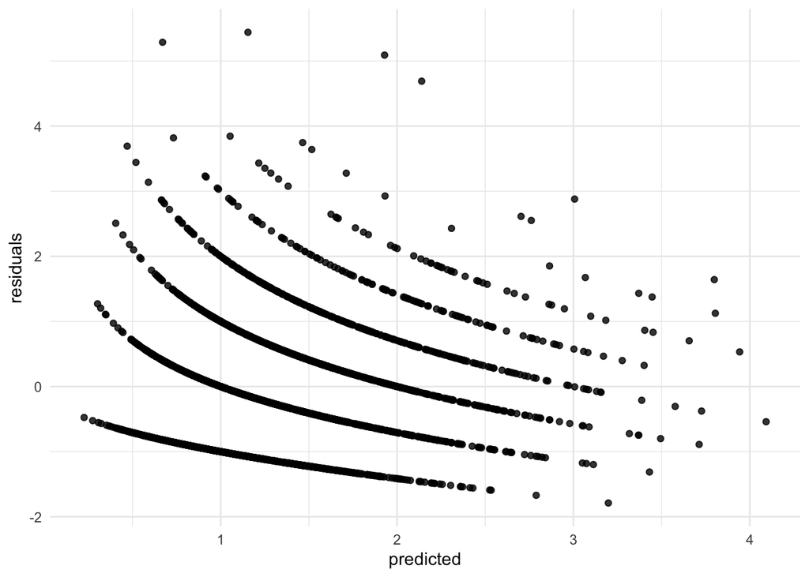

Figure 7: Predicted Values vs Residuals

We can notice that the graph has the particular structure of the discrete value models. That is to say parallel lines each corresponding to a different value taken by the variable `Goal`. We can also remark that there is about the same spacing between each line which is very encouraging.

However, this graph also highlights some high residuals. There is indeed 4 residuals which have a value superior to 4, we display them in the following table :

Figure 8 : Overview of the Data with high residuals.

| Team | Adverse | Goal | Referee | Covid | Home |
| --- | --- | --- | --- | --- | --- |
| Aston Villa | Liverpool | 7 | M Atkinson | During | 2 |
| Man United | Southampton | 9 | M Dean | During | 2 |
| Leicester | Southampton | 9 | A Marriner | Before | 1 |
| West Brom | Chelsea | 5 | D Coote | During | 1 |

Therefore, to know if our model is a good fit, we can do a parametric bootstrap to estimate the model’s deviance. Indeed, the residual deviance is the difference between the current model’s deviance and the ideal model’s maximum deviance, where the predicted values are identical to the observed. The residual deviance of our model is 2988.925, which is more than the degree of freedom: 2709.

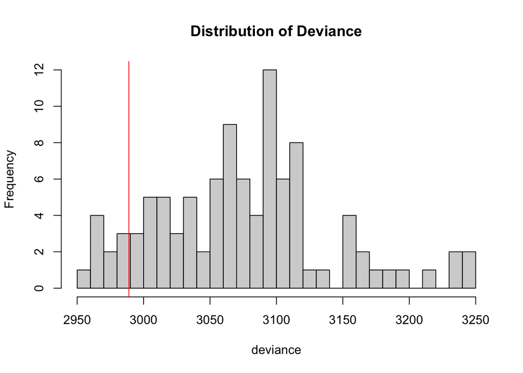

Figure 9: Histogram of the deviance obtained.

Among our hypotheses, we find one that in the same game, the score of each team is independent. This assumption is not intuitive and therefore deserves to be verified. For this, we can plot a team’s residuals against the other team’s residuals in the same match. The result, shown below, is quite convincing. Indeed, no dependence structure is apparent, and the result looks like a normal law of dimension 2. This leads us to affirm that the hypothesis is well-verified.

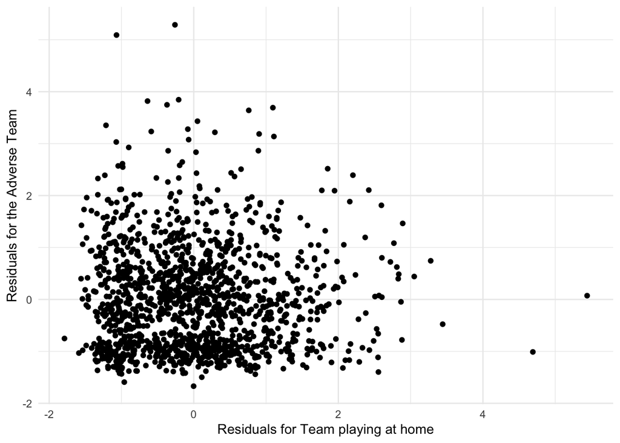

Figure 10: Residuals Comparison, Team vs. Adverse.

# 5 Discussion

In conclusion, we have built a model that represents our observations well. The diagnostics are reasonable, and the hypotheses we have made are verified.

Following this study, we can affirm that the effect of home advantage is real and not negligible in the score prediction. We indeed notice it since the exploration part and the construction of the model confirm it. However we also highlight that it was impacted during the covid. The absence of public reduced the home effect.

Other points of the analysis can also be mentioned such that some teams are better than others in defense or in attack. For example, Man City is the one with the higher coefficient for the variable `Team`, which indicates that they seem very strong in attack. On the other side, Liverpool has the lower coefficient for the `Adverse` variable. So when a Team plays against them, the number of expected scores decreases, which leads us to believe that they are good at defense.

# 6 Larger and Smaller Data set

The first purpose of our report was to highlight changes in the home effect during the three different covid periods. However, we can see that the teams from one season to another are not the same. Consequently, we have some data with the teams present in only one period, and others in two or three. This is not ideal when we want to make an analyse on comparisons, and can indeed increase the uncertainty of the model. We can therefore think about two solutions.

One solution could be to compensate for the lack of information on certain teams by simulating the missing data with our model. It is important to note that the data coming from the simulation, and not from the “real” model will be biased.

```
## Analysis of Deviance Table
##
## Model: poisson, link: log
##
## Response: Goal
##
## Terms added sequentially (first to last)
##
##
##               Df Deviance Resid. Df Resid. Dev  Pr(>Chi)
## NULL                           2814     3644.3
## Team          25   367.67      2789     3276.6 < 2.2e-16 ***
## Adverse       25   185.22      2764     3091.4 < 2.2e-16 ***
## covid          2     0.89      2762     3090.5  0.641797
## home           1    16.31      2761     3074.2  5.38e-05 ***
## covid:home     2     5.82      2759     3068.4  0.054532 .
## Adverse:covid 38    64.78      2721     3003.6  0.004345 **
## ---
## Signif. codes:  0 '***' 0.001 '**' 0.01 '*' 0.05 '.' 0.1 ' ' 1
```

Another possibility could be to analyze only the teams, which have play before, during and after the covid pandemic. The advantage is that none of our observations would be biased. This results in a data set with about 600 fewer observations, which represents a loss of about 21,5 % of the data.

Before doing the regression we can explore this new data set and make the same plot as in the first part. We therefore observe that the impact of covid on the home advantage is not as evident as it was in the first graph. The three curves are indeed more blended, even if looking at the big scores, it seems that the covid still has an impact. Therefore, we could expect different results for the regression.

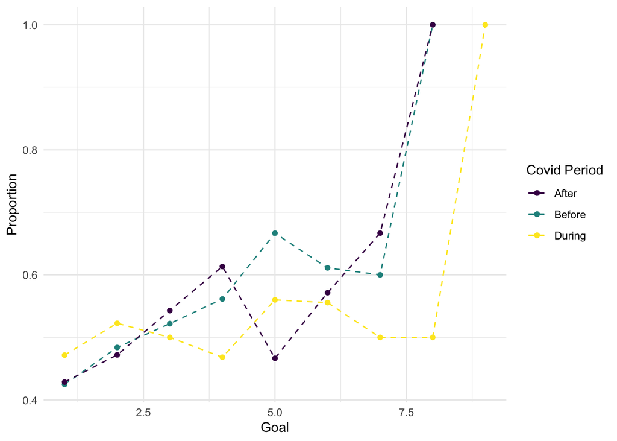

Figure 11: Proportion of goals scored at home for each covid’s periods with the new data set.

```
## Analysis of Deviance Table
##
## Model: poisson, link: log
##
## Response: Goal
##
## Terms added sequentially (first to last)
##
##
##               Df Deviance Resid. Df Resid. Dev  Pr(>Chi)
## NULL                           2201     2763.2
## Team          15  233.165      2186     2530.0 < 2.2e-16 ***
## Adverse       25  155.614      2161     2374.4 < 2.2e-16 ***
## covid          2    0.770      2159     2373.6   0.68060
## home           1   17.173      2158     2356.4 3.412e-05 ***
## covid:home     2    2.963      2156     2353.5   0.22729
## Adverse:covid 35   53.451      2121     2300.0   0.02372 *
## ---
## Signif. codes:  0 '***' 0.001 '**' 0.01 '*' 0.05 '.' 0.1 ' ' 1
```

We find indeed something very curious, the variable `home`*`covid` do not seem to be as significant as it was. This leads us to take a step back from our previous results. And to think that maybe the effect of the covid is not as important as we expected on the home effect. This result could be explained by the fact that the 300 other games that do not have a point of comparison in the other covid periods influence the coefficients and therefore our analysis.